# Forest Fire Data

$~$

## Fitted Model Summary

The outcome model for response Y (increased fire size at the stage being held) is fitted with binomial glm and canonical link, and for Duration_BH, is fitted using gaussian glm and canonical link. The Year^2 is added as the main effect.

For the model with response Y, the interaction are between possible confounders and the treatment (Treatment:Confounders) except for the one between Treatment and Year, which is removed.

For the model with response Duration_BH, the first one comes with all interactions except for the one between Treatment and Year, and the second one includes only interactions between treatment and period, log_IA_size, response time, FWI_Dm1, FWI_D0, eco-region.

$~$

|  | Response: Y W/ All Interactions coef | Response: Y W/ All Interactions 2.5% | Response: Y W/ All Interactions 97.5% | Response: log Duration_BH W/ All Interactions coef | Response: log Duration_BH W/ All Interactions 2.5% | Response: log Duration_BH W/ All Interactions 97.5% | Response: log Duration_BH W/ Partial Interaction coef | Response: log Duration_BH W/ Partial Interaction 2.5% | Response: log Duration_BH W/ Partial Interaction 97.5% |
| --- | --- | --- | --- | --- | --- | --- | --- | --- | --- |
| (Intercept) | 2.1757 | -1.3150 | 5.6663 | 1.5730 | 0.9715 | 2.1744 | 1.3736 | 0.8778 | 1.8695 |
| FWI_Dm1 | 0.0049 | -0.0797 | 0.0895 | -0.0110 | -0.0261 | 0.0041 | -0.0025 | -0.0150 | 0.0099 |
| FWI_Dm2 | -0.0238 | -0.0984 | 0.0508 | 0.0021 | -0.0113 | 0.0155 | -0.0066 | -0.0120 | -0.0011 |
| FWI_D0 | 0.0018 | -0.0712 | 0.0748 | 0.0065 | -0.0063 | 0.0194 | 0.0036 | -0.0085 | 0.0157 |
| FWI_D1 | 0.0078 | -0.0592 | 0.0747 | 0.0197 | 0.0076 | 0.0318 | 0.0132 | 0.0077 | 0.0186 |
| FWI_D2 | -0.0255 | -0.0892 | 0.0382 | -0.0110 | -0.0226 | 0.0005 | 0.0026 | -0.0025 | 0.0077 |
| Year | 0.1960 | -0.1092 | 0.5012 | -0.0585 | -0.1065 | -0.0106 | -0.0509 | -0.0984 | -0.0034 |
| Detection_AgentLKT | -0.2377 | -1.4990 | 1.0237 | -0.2457 | -0.4749 | -0.0165 | -0.3544 | -0.4628 | -0.2460 |
| Detection_AgentUNP | 0.3082 | -1.0588 | 1.6753 | -0.2664 | -0.5036 | -0.0291 | -0.0529 | -0.1605 | 0.0547 |
| Eco_RegionMid-Boreal Uplands | -0.2541 | -1.4259 | 0.9177 | -0.2326 | -0.4306 | -0.0347 | -0.2621 | -0.4580 | -0.0661 |
| Eco_RegionOther | -0.0927 | -1.5918 | 1.4065 | 0.2020 | -0.0579 | 0.4619 | 0.2097 | -0.0474 | 0.4668 |
| Fuel_TypeM2 | 0.6343 | -0.7668 | 2.0353 | 0.5490 | 0.3179 | 0.7801 | 0.5542 | 0.4501 | 0.6584 |
| Fuel_TypeOther | 0.8819 | -0.4971 | 2.2609 | 0.1118 | -0.1155 | 0.3392 | 0.0966 | -0.0061 | 0.1993 |
| TreatmentHAC1R | -1.0827 | -6.1463 | 3.9809 | 0.6529 | -0.1776 | 1.4834 | 1.1464 | 0.5475 | 1.7452 |
| TreatmentHAC1H | -0.4052 | -5.4106 | 4.6003 | -0.1379 | -0.9568 | 0.6809 | 0.0819 | -0.5292 | 0.6931 |
| TreatmentHAC1F | -1.1051 | -6.1478 | 3.9377 | -0.5244 | -1.3329 | 0.2841 | -0.5488 | -1.1514 | 0.0538 |
| TreatmentGround-based action | 0.3400 | -5.5060 | 6.1860 | 0.3481 | -0.4955 | 1.1917 | 0.5810 | -0.0405 | 1.2025 |
| PeriodPM | 0.7716 | -0.7647 | 2.3078 | -0.3405 | -0.6199 | -0.0611 | -0.3058 | -0.5809 | -0.0308 |
| MonthJuly | 0.1063 | -1.4297 | 1.6423 | -1.0750 | -1.3467 | -0.8033 | -1.0448 | -1.1632 | -0.9265 |
| MonthJune or May | -0.4058 | -1.8947 | 1.0831 | -1.0756 | -1.3388 | -0.8125 | -0.9855 | -1.1031 | -0.8679 |
| log_Response_Time | -0.0935 | -0.3281 | 0.1410 | 0.0715 | 0.0338 | 0.1092 | 0.0865 | 0.0510 | 0.1220 |
| log_Count_Fire_Overlap | -0.5513 | -1.1027 | 0.0001 | 0.5345 | 0.4382 | 0.6308 | 0.5322 | 0.4890 | 0.5754 |
| log_IA_size | -0.2564 | -0.4851 | -0.0277 | 0.1843 | 0.1421 | 0.2265 | 0.1892 | 0.1486 | 0.2297 |
| I(Year^2) | -0.0148 | -0.0391 | 0.0095 | 0.0022 | -0.0016 | 0.0061 | 0.0018 | -0.0020 | 0.0056 |
| FWI_Dm1:TreatmentHAC1R | 0.0246 | -0.0922 | 0.1414 | 0.0125 | -0.0074 | 0.0324 | 0.0070 | -0.0094 | 0.0233 |
| FWI_Dm1:TreatmentHAC1H | 0.0049 | -0.1154 | 0.1252 | 0.0040 | -0.0165 | 0.0245 | -0.0016 | -0.0181 | 0.0149 |
| FWI_Dm1:TreatmentHAC1F | -0.0139 | -0.1341 | 0.1062 | 0.0241 | 0.0036 | 0.0447 | 0.0151 | -0.0013 | 0.0316 |
| FWI_Dm1:TreatmentGround-based action | 0.0173 | -0.1078 | 0.1424 | 0.0041 | -0.0160 | 0.0241 | -0.0054 | -0.0221 | 0.0113 |
| FWI_Dm2:TreatmentHAC1R | 0.0053 | -0.0938 | 0.1045 | -0.0059 | -0.0232 | 0.0114 | NA | NA | NA |
| FWI_Dm2:TreatmentHAC1H | 0.0219 | -0.0868 | 0.1306 | -0.0042 | -0.0229 | 0.0145 | NA | NA | NA |

[output cut: 62 more lines]

# Benefit Table on Duration_BH

The effect brought by each treatment on Duration_BH according to our model is computed. The baseline is *Air Tanker*. The first colomn is sample ID. The first 30 samples are presented below. The second colomn is the treatment that is actually selected and applied. The third colomn is the treatment with the highest propensity score. And the “Best Treatment” colomns gives the treatment that has the “most negative effect” as we want the best treatment will be the one that minimize the Duration_BH.

|  | Treatment Applied | Treatment Predicted | Model W/ All Interations Benefit HAC1R | Model W/ All Interations Benefit HAC1H | Model W/ All Interations Benefit HAC1F | Model W/ All Interations Benefit Ground-based action | Model W/ All Interations Best Treatment | Model W/ Partial Interaction Benefit HAC1R | Model W/ Partial Interaction Benefit HAC1H | Model W/ Partial Interaction Benefit HAC1F | Model W/ Partial Interaction Benefit Ground-based action | Model W/ Partial Interaction Best Treatment Predicted |
| --- | --- | --- | --- | --- | --- | --- | --- | --- | --- | --- | --- | --- |
| 3157 | Air Tanker | HAC1H | 0.1987 | -0.2954 | 0.3164 | 0.5057 | HAC1H | 0.1482 | -0.145 | 0.062 | 0.4659 | HAC1H |
| 3158 | HAC1H | HAC1H | -0.1858 | -0.0579 | 0.2752 | 0.8085 | HAC1R | -0.1635 | 0.114 | 0.2469 | 0.7679 | HAC1R |
| 3159 | Air Tanker | HAC1H | -0.2769 | 0.0516 | -0.2496 | 0.4138 | HAC1R | -0.4142 | 0.0851 | -0.4007 | 0.1271 | HAC1R |
| 3160 | Air Tanker | HAC1H | -0.3682 | -0.307 | -0.6035 | -0.1758 | HAC1F | -0.3654 | -0.1913 | -0.7372 | -0.3038 | HAC1F |
| 3161 | Ground-based action | HAC1H | -0.2232 | -0.0153 | 0.3041 | 0.7604 | HAC1R | -0.2762 | 0.0857 | 0.2258 | 0.6287 | HAC1R |
| 3162 | HAC1H | HAC1H | 0.2015 | -0.0048 | 0.4046 | 0.9287 | HAC1H | 0.0418 | -0.0495 | 0.1236 | 0.5978 | HAC1H |
| 3163 | HAC1F | HAC1H | 0.1526 | -0.2929 | -0.2454 | 0.6029 | HAC1H | 0.1426 | -0.2568 | -0.451 | 0.2446 | HAC1F |
| 3164 | HAC1F | Air Tanker | 0.7098 | 0.0509 | 0.6702 | 1.0279 | Air Tanker | 0.1258 | -0.1859 | 0.0031 | 0.3721 | HAC1H |
| 3165 | Air Tanker | HAC1H | -0.0094 | -0.0959 | 0.3112 | 0.7257 | HAC1H | -0.1573 | -0.0832 | 0.0245 | 0.4185 | HAC1R |
| 3166 | Air Tanker | HAC1H | 0.0229 | -0.1071 | 0.3296 | 0.7268 | HAC1H | -0.1249 | -0.1 | 0.0255 | 0.4119 | HAC1R |
| 3167 | HAC1H | HAC1H | -0.203 | -0.25 | 0.3173 | 0.1766 | HAC1H | -0.2528 | -0.1045 | 0.2004 | 0.2067 | HAC1R |
| 3168 | Air Tanker | HAC1H | -0.1181 | -0.1038 | 0.5573 | 0.2997 | HAC1R | -0.3104 | -0.0973 | 0.3111 | 0.089 | HAC1R |
| 3169 | Air Tanker | HAC1H | -0.1464 | -0.064 | 0.629 | 0.3539 | HAC1R | -0.3472 | -0.0689 | 0.3785 | 0.1152 | HAC1R |
| 3170 | HAC1R | HAC1H | -0.4915 | -0.5226 | 0.2957 | -0.2428 | HAC1H | -0.4562 | -0.2724 | -0.3606 | -0.0754 | HAC1R |
| 3171 | HAC1H | HAC1H | -0.7349 | -0.4668 | -0.5323 | -0.6698 | HAC1R | -0.7395 | -0.0808 | -0.1672 | 0.0394 | HAC1R |
| 3172 | Ground-based action | HAC1H | -0.687 | -0.172 | 0.7154 | -0.0486 | HAC1R | -0.412 | 0.033 | 0.4474 | 0.3178 | HAC1R |
| 3173 | HAC1H | HAC1H | -0.1399 | -0.402 | -0.0018 | 0.1644 | HAC1H | 0.0047 | -0.1652 | 0.007 | 0.3416 | HAC1H |
| 3174 | HAC1F | Air Tanker | -0.1601 | -0.4089 | 0.0639 | 0.0656 | HAC1H | -0.0574 | -0.2171 | 0.0172 | 0.1776 | HAC1H |
| 3175 | Air Tanker | HAC1H | -0.4876 | -0.2093 | 0.129 | 0.2128 | HAC1R | -0.4104 | -0.0078 | 0.2027 | 0.3035 | HAC1R |
| 3176 | HAC1H | Air Tanker | -0.1827 | -0.427 | -0.1151 | 0.2504 | HAC1H | -0.0428 | -0.1826 | -0.1606 | 0.3461 | HAC1H |
| 3177 | HAC1F | HAC1H | -0.4361 | -0.2816 | -0.0014 | 0.1143 | HAC1R | -0.3434 | -0.0595 | 0.0801 | 0.2557 | HAC1R |
| 3178 | Air Tanker | HAC1H | -0.162 | 0.0646 | 0.4526 | 0.3724 | HAC1R | -0.72 | -0.1175 | 0.0555 | -0.1124 | HAC1R |
| 3179 | Air Tanker | Air Tanker | 0.275 | -0.3053 | 0.4474 | 0.3414 | HAC1H | 0.2878 | -0.2285 | 0.2491 | 0.3102 | HAC1H |
| 3180 | HAC1H | HAC1H | -0.2704 | -0.0809 | 0.0575 | 0.1245 | HAC1R | -0.0391 | 2e-04 | -0.359 | 0.229 | HAC1F |
| 3181 | Ground-based action | HAC1H | 0.5597 | 0.4218 | 0.55 | 0.5662 | Air Tanker | 0.0052 | 0.199 | 0.0905 | -0.0813 | Ground-based action |
| 3182 | HAC1R | HAC1H | 0.4077 | 0.0401 | 0.6111 | 0.2322 | Air Tanker | 0.4512 | 0.1944 | 0.5714 | 0.1543 | Air Tanker |
| 3183 | HAC1R | HAC1H | 0.0673 | -0.5316 | -0.3701 | -0.3784 | HAC1H | 0.2796 | -0.2759 | -0.2815 | -0.0906 | HAC1F |
| 3184 | HAC1H | HAC1H | -0.394 | -0.194 | 0.4001 | 0.332 | HAC1R | -0.1428 | -0.0447 | 0.0013 | 0.511 | HAC1R |
| 3186 | HAC1H | HAC1H | 0.4488 | -0.2712 | -0.2638 | 0.4713 | HAC1H | 0.0759 | -0.2409 | -0.5994 | 0.3004 | HAC1F |
| 3187 | HAC1H | HAC1H | -0.1336 | -0.1712 | 0.1446 | 0.5341 | HAC1H | -0.1633 | -0.0584 | 0.0317 | 0.45 | HAC1R |

```
##      HAC1R              HAC1H              HAC1F          Ground-based action
##  Min.   :-1.54419   Min.   :-1.04406   Min.   :-1.75291   Min.   :-2.1481
##  1st Qu.:-0.38944   1st Qu.:-0.24025   1st Qu.:-0.38135   1st Qu.:-0.1182
##  Median :-0.12898   Median :-0.09120   Median :-0.06218   Median : 0.2295
##  Mean   :-0.08708   Mean   :-0.06219   Mean   :-0.06338   Mean   : 0.2183
##  3rd Qu.: 0.18606   3rd Qu.: 0.09617   3rd Qu.: 0.25341   3rd Qu.: 0.5733
##  Max.   : 1.56781   Max.   : 1.01427   Max.   : 1.69067   Max.   : 2.0212
```

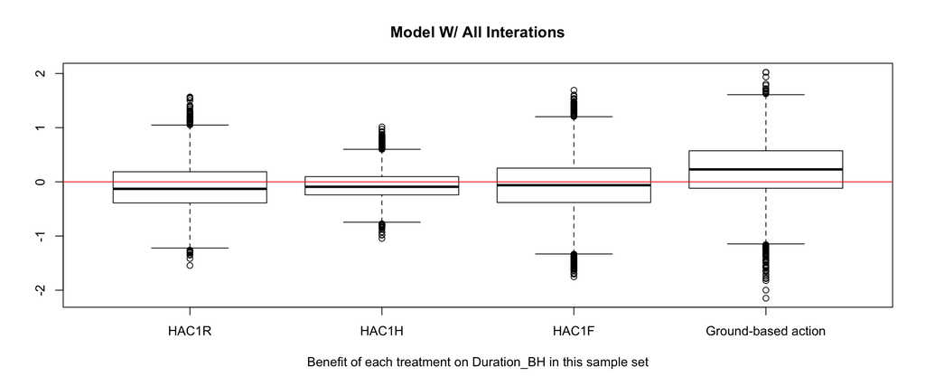

```
##      HAC1R              HAC1H              HAC1F          Ground-based action
##  Min.   :-1.19871   Min.   :-0.99857   Min.   :-1.42479   Min.   :-1.50887
##  1st Qu.:-0.28999   1st Qu.:-0.19145   1st Qu.:-0.33814   1st Qu.:-0.05546
##  Median :-0.10615   Median :-0.07899   Median :-0.03000   Median : 0.22086
##  Mean   :-0.06186   Mean   :-0.05988   Mean   :-0.06088   Mean   : 0.22327
##  3rd Qu.: 0.12254   3rd Qu.: 0.03623   3rd Qu.: 0.17676   3rd Qu.: 0.50161
##  Max.   : 1.28019   Max.   : 0.63146   Max.   : 1.25951   Max.   : 1.48952
```

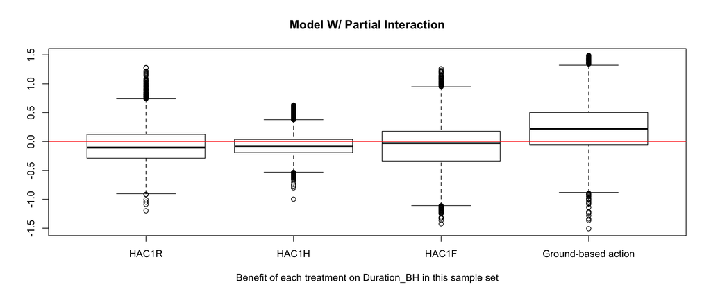

## Characteristics of Fires Under Each Best Treatment

Here is the table for the model with all interactions.

```
##                                     Stratified by Treatment
##                                      Air Tanker    HAC1R         HAC1H         HAC1F         Ground-based action SMD
##   n                                   1001          1736           855          1481           366
##   FWI_Dm1 (mean (SD))                11.29 (8.78)  12.91 (8.71)  13.45 (9.01)  10.40 (7.85)  23.21 (10.80)        0.586
##   FWI_Dm2 (mean (SD))                 9.70 (8.00)  11.73 (8.51)  10.91 (8.14)  10.80 (8.67)  23.15 (14.13)        0.501
##   FWI_D0 (mean (SD))                  8.85 (7.81)  14.17 (9.27)  11.81 (7.73)  11.46 (8.14)  22.72 (10.73)        0.664
##   FWI_D1 (mean (SD))                  7.79 (8.09)   8.69 (8.96)   9.43 (8.87)   8.35 (8.51)  16.04 (12.77)        0.336
##   FWI_D2 (mean (SD))                 10.32 (10.09)  8.07 (8.87)   7.45 (7.78)   8.01 (8.46)  10.06 (11.78)        0.163
##   Year (mean (SD))                    7.01 (3.75)   5.81 (3.20)   5.90 (3.13)   5.56 (3.03)   5.58 (3.14)         0.190
##   Detection_Agent (%)                                                                                             0.691
##      AIR                                81 ( 8.1)    449 (25.9)     90 (10.5)    539 (36.4)     41 (11.2)
##      LKT                               252 (25.2)   1048 (60.4)    561 (65.6)    627 (42.3)    211 (57.7)
##      UNP                               668 (66.7)    239 (13.8)    204 (23.9)    315 (21.3)    114 (31.1)
##   Eco_Region (%)                                                                                                  1.017
##      Clear Hills Upland                158 (15.8)    396 (22.8)      2 ( 0.2)    745 (50.3)    151 (41.3)
##      Mid-Boreal Uplands                697 (69.6)   1231 (70.9)    764 (89.4)    477 (32.2)     68 (18.6)
##      Other                             146 (14.6)    109 ( 6.3)     89 (10.4)    259 (17.5)    147 (40.2)
##   Fuel_Type (%)                                                                                                   0.913
##      C2                                655 (65.4)   1128 (65.0)    632 (73.9)   1274 (86.0)     92 (25.1)
##      M2                                186 (18.6)    564 (32.5)     54 ( 6.3)     52 ( 3.5)     36 ( 9.8)
##      Other                             160 (16.0)     44 ( 2.5)    169 (19.8)    155 (10.5)    238 (65.0)
##   Period = PM (%)                      512 (51.1)   1688 (97.2)    837 (97.9)   1420 (95.9)    346 (94.5)         0.541
##   Month (%)                                                                                                       0.616
##      August to October                 193 (19.3)    489 (28.2)     38 ( 4.4)     85 ( 5.7)    117 (32.0)
##      July                              431 (43.1)    616 (35.5)    269 (31.5)   1029 (69.5)    153 (41.8)
##      June or May                       377 (37.7)    631 (36.3)    548 (64.1)    367 (24.8)     96 (26.2)
##   log_Duration_BH (mean (SD))         2.21 (1.59)   1.97 (1.75)   1.87 (1.41)   1.77 (1.63)   2.26 (1.66)         0.163
##   log_Response_Time (mean (SD))       7.45 (1.60)   7.58 (1.55)   6.45 (2.35)   4.85 (3.14)   6.39 (2.65)         0.547
##   log_Count_Fire_Overlap (mean (SD))  3.49 (1.02)   3.69 (0.95)   3.52 (1.05)   4.11 (0.89)   3.90 (1.08)         0.327
##   log_IA_size (mean (SD))            -2.77 (1.97)  -3.51 (1.55)  -0.83 (2.08)  -2.73 (2.12)  -1.98 (2.42)         0.613
```

Here is the table for the model with partial interactions.

```
##                                     Stratified by Treatment
##                                      Air Tanker    HAC1R         HAC1H         HAC1F         Ground-based action SMD
##   n                                    624          1985          1128          1503           199
##   FWI_Dm1 (mean (SD))                11.18 (8.41)  12.94 (8.67)  13.52 (9.04)  10.20 (7.79)  29.42 (9.74)         0.905
##   FWI_Dm2 (mean (SD))                10.29 (8.41)  11.89 (9.21)  11.66 (9.62)  10.49 (8.60)  24.79 (9.83)         0.651
##   FWI_D0 (mean (SD))                  9.28 (8.21)  14.54 (9.20)  10.08 (7.22)  11.43 (8.23)  28.40 (8.97)         1.001
##   FWI_D1 (mean (SD))                  7.57 (8.03)   9.18 (9.42)   8.46 (8.13)   8.43 (8.43)  20.27 (13.14)        0.486
##   FWI_D2 (mean (SD))                  7.75 (8.18)   8.83 (9.62)   8.37 (8.22)   7.53 (8.10)  15.89 (14.15)        0.318
##   Year (mean (SD))                    8.29 (3.80)   5.61 (3.11)   5.82 (3.13)   5.59 (3.01)   5.76 (3.38)         0.324
##   Detection_Agent (%)                                                                                             0.317
##      AIR                                94 (15.1)    347 (17.5)    183 (16.2)    536 (35.7)     40 (20.1)
##      LKT                               288 (46.2)   1067 (53.8)    698 (61.9)    543 (36.1)    103 (51.8)
##      UNP                               242 (38.8)    571 (28.8)    247 (21.9)    424 (28.2)     56 (28.1)
##   Eco_Region (%)                                                                                                  1.474
##      Clear Hills Upland                135 (21.6)    448 (22.6)      1 ( 0.1)    817 (54.4)     51 (25.6)
##      Mid-Boreal Uplands                387 (62.0)   1486 (74.9)   1002 (88.8)    353 (23.5)      9 ( 4.5)
##      Other                             102 (16.3)     51 ( 2.6)    125 (11.1)    333 (22.2)    139 (69.8)
##   Fuel_Type (%)                                                                                                   0.264
##      C2                                383 (61.4)   1370 (69.0)    896 (79.4)   1013 (67.4)    119 (59.8)
##      M2                                145 (23.2)    368 (18.5)     97 ( 8.6)    249 (16.6)     33 (16.6)
##      Other                              96 (15.4)    247 (12.4)    135 (12.0)    241 (16.0)     47 (23.6)
##   Period = PM (%)                       49 ( 7.9)   1974 (99.4)   1122 (99.5)   1471 (97.9)    187 (94.0)         1.795
##   Month (%)                                                                                                       0.238
##      August to October                 183 (29.3)    310 (15.6)    126 (11.2)    254 (16.9)     49 (24.6)
##      July                              223 (35.7)    927 (46.7)    557 (49.4)    709 (47.2)     82 (41.2)
##      June or May                       218 (34.9)    748 (37.7)    445 (39.5)    540 (35.9)     68 (34.2)
##   log_Duration_BH (mean (SD))         2.50 (1.61)   1.72 (1.58)   2.12 (1.50)   1.86 (1.72)   2.70 (1.81)         0.315
##   log_Response_Time (mean (SD))       7.49 (1.71)   7.64 (1.51)   6.89 (1.64)   4.44 (3.22)   6.97 (2.06)         0.596
##   log_Count_Fire_Overlap (mean (SD))  3.38 (1.00)   3.68 (0.97)   3.92 (0.99)   3.84 (0.98)   4.11 (1.23)         0.327
##   log_IA_size (mean (SD))            -2.74 (2.00)  -3.72 (1.39)  -0.58 (1.87)  -2.86 (1.96)  -1.45 (2.64)         0.795
```

[output not shown]

```
## [1] "How many best treatment predicted are the same for these 2 models (full and partial interactions): 0.644787644787645"
```

## Study on Fire Size

Here, the model with *log(Being_Held_Size / Initial_Assessment_Size)* and the model with *log(Extinction_Size / Initial_Assessment_Size)* as the response is studied. Though effects of “Treatment” on Y and Duration_BH are kind of kind of counterintuitive, after variable selection, the model in which most variables are significant is given below and they might reveal something more about the effect of each treatment. Actually, the model with all interactions gives almost the same trend while main effect of Treatment are kept significant, so to make the pattern maybe more clear, I discard some varaibles with low p values.

Both two log transformed size ratio are heavily right skewed.

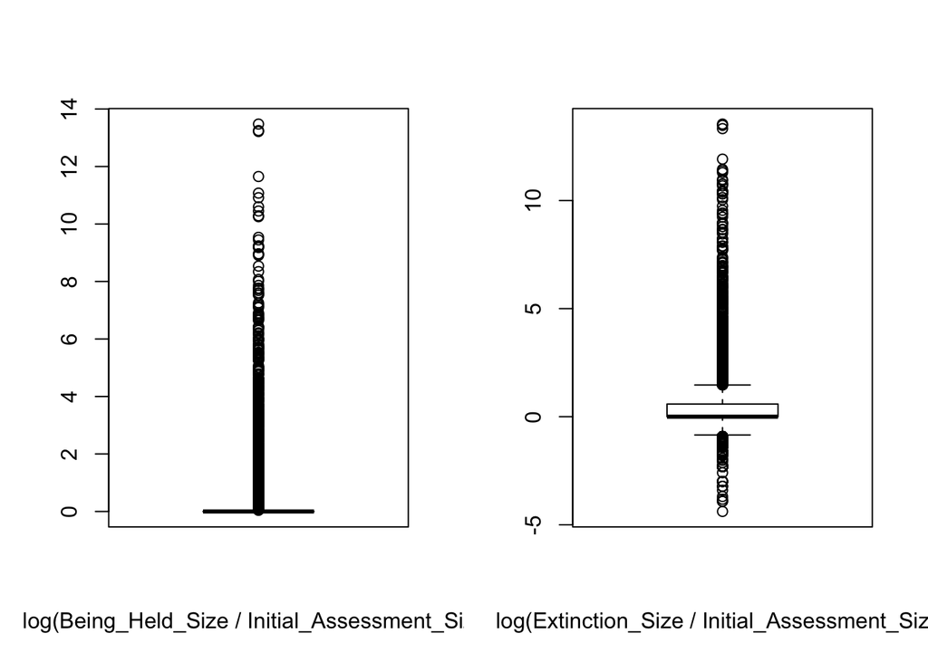

```r
## The response here is log(Being_Held_Size / Initial_Assessment_Size)
m_size1 = glm(size1~.+Treatment:.- Treatment:Year-Treatment:Month - Treatment:FWI_Dm1 - Treatment:FWI_Dm2 - Treatment:FWI_D1 - Treatment:FWI_D2 -Treatment:Fuel_Type - Treatment:Eco_Region - Treatment:Detection_Agent -FWI_Dm1 - FWI_Dm2 - FWI_D2, weights = OW, family = "gaussian",data=dt2)
summary(m_size1)
```

```
##
## Call:
## glm(formula = size1 ~ . + Treatment:. - Treatment:Year - Treatment:Month -
##     Treatment:FWI_Dm1 - Treatment:FWI_Dm2 - Treatment:FWI_D1 -
##     Treatment:FWI_D2 - Treatment:Fuel_Type - Treatment:Eco_Region -
##     Treatment:Detection_Agent - FWI_Dm1 - FWI_Dm2 - FWI_D2, family = "gaussian",
##     data = dt2, weights = OW)
##
## Deviance Residuals:
##     Min       1Q   Median       3Q      Max
## -1.2150  -0.1378  -0.0521   0.0213   6.8525
##
## Coefficients:
##                                                      Estimate Std. Error t value Pr(>|t|)
## (Intercept)                                         -2.235860   0.260880  -8.570  < 2e-16 ***
## FWI_D0                                               0.020474   0.004539   4.511 6.59e-06 ***
## FWI_D1                                               0.009133   0.002170   4.209 2.61e-05 ***
## Year                                                -0.010078   0.005951  -1.694 0.090392 .
## Detection_AgentLKT                                   0.129601   0.051946   2.495 0.012628 *
## Detection_AgentUNP                                  -0.043431   0.051651  -0.841 0.400471
## Eco_RegionMid-Boreal Uplands                         0.228232   0.041791   5.461 4.94e-08 ***
## Eco_RegionOther                                      0.152478   0.057780   2.639 0.008341 **
## Fuel_TypeM2                                         -0.181967   0.049865  -3.649 0.000266 ***
## Fuel_TypeOther                                       0.082705   0.049053   1.686 0.091847 .
## TreatmentHAC1R                                       2.328445   0.342577   6.797 1.18e-11 ***
## TreatmentHAC1H                                       1.693989   0.344039   4.924 8.74e-07 ***
## TreatmentHAC1F                                       2.461398   0.343615   7.163 8.94e-13 ***
## TreatmentGround-based action                         1.268188   0.348199   3.642 0.000273 ***
## PeriodPM                                            -0.779910   0.130037  -5.998 2.13e-09 ***
## MonthJuly                                           -0.097282   0.056563  -1.720 0.085513 .
## MonthJune or May                                     0.111092   0.055970   1.985 0.047212 *
## log_Response_Time                                    0.082103   0.016972   4.838 1.35e-06 ***
## log_Count_Fire_Overlap                               0.667781   0.042104  15.860  < 2e-16 ***
## log_IA_size                                         -0.052792   0.019404  -2.721 0.006537 **
## FWI_D0:TreatmentHAC1R                               -0.026001   0.006285  -4.137 3.57e-05 ***
## FWI_D0:TreatmentHAC1H                               -0.013792   0.006091  -2.264 0.023597 *
## FWI_D0:TreatmentHAC1F                               -0.019448   0.006298  -3.088 0.002024 **
## FWI_D0:TreatmentGround-based action                 -0.005049   0.005997  -0.842 0.399948
## TreatmentHAC1R:PeriodPM                              0.365259   0.182572   2.001 0.045482 *
## TreatmentHAC1H:PeriodPM                              0.720043   0.178477   4.034 5.55e-05 ***
```

[output cut: 9 more lines]

```
## TreatmentGround-based action:log_Count_Fire_Overlap -0.387069   0.057543  -6.727 1.92e-11 ***
## TreatmentHAC1R:log_IA_size                           0.127965   0.027115   4.719 2.43e-06 ***
## TreatmentHAC1H:log_IA_size                           0.098549   0.027423   3.594 0.000329 ***
## TreatmentHAC1F:log_IA_size                           0.082761   0.027776   2.980 0.002899 **
## TreatmentGround-based action:log_IA_size             0.048814   0.026901   1.815 0.069651 .
## ---
## Signif. codes:  0 '***' 0.001 '**' 0.01 '*' 0.05 '.' 0.1 ' ' 1
##
## (Dispersion parameter for gaussian family taken to be 0.1656446)
##
##     Null deviance: 1040.25  on 5438  degrees of freedom
## Residual deviance:  894.32  on 5399  degrees of freedom
## AIC: 20511
##
## Number of Fisher Scoring iterations: 2
```

```r
## The response here is log(Extinction_Size / Initial_Assessment_Size)
m_size2 = glm(size2~.+Treatment:.- Treatment:Year-Treatment:Month - Treatment:FWI_Dm1 - Treatment:FWI_Dm2 - Treatment:FWI_D1 - Treatment:FWI_D2 -Treatment:Fuel_Type - Treatment:Eco_Region - Treatment:Detection_Agent -FWI_Dm1 - FWI_Dm2 - FWI_D2, weights = OW, family = "gaussian",data=dt2)
summary(m_size2)
```

```
##
## Call:
## glm(formula = size2 ~ . + Treatment:. - Treatment:Year - Treatment:Month -
##     Treatment:FWI_Dm1 - Treatment:FWI_Dm2 - Treatment:FWI_D1 -
##     Treatment:FWI_D2 - Treatment:Fuel_Type - Treatment:Eco_Region -
##     Treatment:Detection_Agent - FWI_Dm1 - FWI_Dm2 - FWI_D2, family = "gaussian",
##     data = dt2, weights = OW)
##
## Deviance Residuals:
##     Min       1Q   Median       3Q      Max
## -2.3835  -0.1688  -0.0545   0.0687   6.7295
##
## Coefficients:
##                                                      Estimate Std. Error t value Pr(>|t|)
## (Intercept)                                         -2.842387   0.310108  -9.166  < 2e-16 ***
## FWI_D0                                               0.022043   0.005395   4.086 4.46e-05 ***
## FWI_D1                                               0.013564   0.002579   5.258 1.51e-07 ***
## Year                                                 0.001427   0.007073   0.202 0.840093
## Detection_AgentLKT                                   0.194589   0.061748   3.151 0.001634 **
## Detection_AgentUNP                                  -0.027413   0.061398  -0.446 0.655265
## Eco_RegionMid-Boreal Uplands                         0.307282   0.049677   6.186 6.64e-10 ***
## Eco_RegionOther                                      0.453848   0.068683   6.608 4.28e-11 ***
## Fuel_TypeM2                                         -0.179236   0.059275  -3.024 0.002508 **
## Fuel_TypeOther                                       0.138066   0.058309   2.368 0.017928 *
## TreatmentHAC1R                                       2.179630   0.407222   5.352 9.04e-08 ***
## TreatmentHAC1H                                       1.591249   0.408960   3.891 0.000101 ***
## TreatmentHAC1F                                       2.522913   0.408456   6.177 7.02e-10 ***
## TreatmentGround-based action                         0.709066   0.413905   1.713 0.086749 .
## PeriodPM                                            -0.880658   0.154575  -5.697 1.28e-08 ***
## MonthJuly                                           -0.171548   0.067237  -2.551 0.010757 *
## MonthJune or May                                     0.190946   0.066532   2.870 0.004121 **
## log_Response_Time                                    0.080588   0.020175   3.994 6.57e-05 ***
## log_Count_Fire_Overlap                               0.762075   0.050049  15.226  < 2e-16 ***
## log_IA_size                                         -0.101315   0.023066  -4.392 1.14e-05 ***
## FWI_D0:TreatmentHAC1R                               -0.039923   0.007471  -5.344 9.46e-08 ***
## FWI_D0:TreatmentHAC1H                               -0.018145   0.007240  -2.506 0.012239 *
## FWI_D0:TreatmentHAC1F                               -0.020705   0.007486  -2.766 0.005699 **
## FWI_D0:TreatmentGround-based action                 -0.003001   0.007129  -0.421 0.673773
## TreatmentHAC1R:PeriodPM                              0.590847   0.217024   2.723 0.006500 **
## TreatmentHAC1H:PeriodPM                              0.770970   0.212156   3.634 0.000282 ***
```

[output cut: 9 more lines]

```
## TreatmentGround-based action:log_Count_Fire_Overlap -0.269851   0.068402  -3.945 8.08e-05 ***
## TreatmentHAC1R:log_IA_size                           0.165180   0.032232   5.125 3.08e-07 ***
## TreatmentHAC1H:log_IA_size                           0.129058   0.032597   3.959 7.62e-05 ***
## TreatmentHAC1F:log_IA_size                           0.071845   0.033018   2.176 0.029601 *
## TreatmentGround-based action:log_IA_size             0.117502   0.031978   3.674 0.000241 ***
## ---
## Signif. codes:  0 '***' 0.001 '**' 0.01 '*' 0.05 '.' 0.1 ' ' 1
##
## (Dispersion parameter for gaussian family taken to be 0.2340583)
##
##     Null deviance: 1502.8  on 5438  degrees of freedom
## Residual deviance: 1263.7  on 5399  degrees of freedom
## AIC: 22391
##
## Number of Fisher Scoring iterations: 2
```

```r
## The response here is log(Duration_BH). It is under the same set of variable
m_size3 = glm(dt$log_Duration_BH~.+Treatment:.- Treatment:Year-Treatment:Month - Treatment:FWI_Dm1 - Treatment:FWI_Dm2 - Treatment:FWI_D1 - Treatment:FWI_D2 -Treatment:Fuel_Type - Treatment:Eco_Region - Treatment:Detection_Agent -FWI_Dm1 - FWI_Dm2 - FWI_D2, weights = OW, family = "gaussian",data=dt2)
summary(m_size3)
```

```
##
## Call:
## glm(formula = dt$log_Duration_BH ~ . + Treatment:. - Treatment:Year -
##     Treatment:Month - Treatment:FWI_Dm1 - Treatment:FWI_Dm2 -
##     Treatment:FWI_D1 - Treatment:FWI_D2 - Treatment:Fuel_Type -
##     Treatment:Eco_Region - Treatment:Detection_Agent - FWI_Dm1 -
##     FWI_Dm2 - FWI_D2, family = "gaussian", data = dt2, weights = OW)
##
## Deviance Residuals:
##     Min       1Q   Median       3Q      Max
## -1.7202  -0.2389  -0.0436   0.2154   3.3161
##
## Coefficients:
##                                                       Estimate Std. Error t value Pr(>|t|)
## (Intercept)                                          1.217e+00  2.781e-01   4.377 1.23e-05 ***
## FWI_D0                                              -9.986e-05  4.839e-03  -0.021 0.983535
## FWI_D1                                               1.402e-02  2.313e-03   6.061 1.45e-09 ***
## Year                                                -3.061e-02  6.344e-03  -4.825 1.44e-06 ***
## Detection_AgentLKT                                  -3.381e-01  5.538e-02  -6.105 1.10e-09 ***
## Detection_AgentUNP                                  -4.077e-02  5.507e-02  -0.740 0.459075
## Eco_RegionMid-Boreal Uplands                        -1.876e-02  4.455e-02  -0.421 0.673756
## Eco_RegionOther                                      2.986e-01  6.160e-02   4.848 1.28e-06 ***
## Fuel_TypeM2                                          5.587e-01  5.316e-02  10.509  < 2e-16 ***
## Fuel_TypeOther                                       1.037e-01  5.230e-02   1.984 0.047353 *
## TreatmentHAC1R                                       1.257e+00  3.652e-01   3.442 0.000581 ***
## TreatmentHAC1H                                      -2.239e-01  3.668e-01  -0.610 0.541593
## TreatmentHAC1F                                       1.550e-01  3.663e-01   0.423 0.672196
## TreatmentGround-based action                         6.462e-01  3.712e-01   1.741 0.081801 .
## PeriodPM                                            -3.373e-01  1.386e-01  -2.433 0.015009 *
## MonthJuly                                           -1.041e+00  6.030e-02 -17.269  < 2e-16 ***
## MonthJune or May                                    -9.920e-01  5.967e-02 -16.624  < 2e-16 ***
## log_Response_Time                                    8.489e-02  1.809e-02   4.691 2.78e-06 ***
## log_Count_Fire_Overlap                               5.139e-01  4.489e-02  11.448  < 2e-16 ***
## log_IA_size                                          1.850e-01  2.069e-02   8.941  < 2e-16 ***
## FWI_D0:TreatmentHAC1R                               -2.027e-02  6.700e-03  -3.026 0.002491 **
## FWI_D0:TreatmentHAC1H                               -7.890e-03  6.494e-03  -1.215 0.224417
## FWI_D0:TreatmentHAC1F                               -5.382e-03  6.714e-03  -0.802 0.422792
## FWI_D0:TreatmentGround-based action                 -2.813e-02  6.394e-03  -4.400 1.10e-05 ***
## TreatmentHAC1R:PeriodPM                             -6.933e-01  1.946e-01  -3.562 0.000371 ***
## TreatmentHAC1H:PeriodPM                             -4.218e-01  1.903e-01  -2.217 0.026682 *
```

[output cut: 9 more lines]

```
## TreatmentGround-based action:log_Count_Fire_Overlap  2.718e-02  6.135e-02   0.443 0.657718
## TreatmentHAC1R:log_IA_size                           6.892e-02  2.891e-02   2.384 0.017149 *
## TreatmentHAC1H:log_IA_size                          -5.096e-02  2.924e-02  -1.743 0.081384 .
## TreatmentHAC1F:log_IA_size                          -4.435e-03  2.961e-02  -0.150 0.880952
## TreatmentGround-based action:log_IA_size            -2.550e-02  2.868e-02  -0.889 0.373999
## ---
## Signif. codes:  0 '***' 0.001 '**' 0.01 '*' 0.05 '.' 0.1 ' ' 1
##
## (Dispersion parameter for gaussian family taken to be 0.1882737)
##
##     Null deviance: 1444.2  on 5438  degrees of freedom
## Residual deviance: 1016.5  on 5399  degrees of freedom
## AIC: 21207
##
## Number of Fisher Scoring iterations: 2
```

```r
m_size4 = glm(size1~., weights = OW, family = "gaussian",data=dt2)
summary(m_size4)
```

```
##
## Call:
## glm(formula = size1 ~ ., family = "gaussian", data = dt2, weights = OW)
##
## Deviance Residuals:
##     Min       1Q   Median       3Q      Max
## -1.1277  -0.1588  -0.0567   0.0246   7.6974
##
## Coefficients:
##                                Estimate Std. Error t value Pr(>|t|)
## (Intercept)                  -0.4116051  0.1477125  -2.787 0.005346 **
## FWI_Dm1                      -0.0047668  0.0029494  -1.616 0.106108
## FWI_Dm2                       0.0060355  0.0026381   2.288 0.022190 *
## FWI_D0                        0.0088771  0.0026820   3.310 0.000939 ***
## FWI_D1                        0.0081141  0.0026355   3.079 0.002089 **
## FWI_D2                        0.0009721  0.0024812   0.392 0.695238
## Year                         -0.0094366  0.0059616  -1.583 0.113502
## Detection_AgentLKT            0.1242358  0.0524571   2.368 0.017904 *
## Detection_AgentUNP           -0.0560937  0.0519862  -1.079 0.280631
## Eco_RegionMid-Boreal Uplands  0.2485979  0.0422868   5.879 4.38e-09 ***
## Eco_RegionOther               0.1521400  0.0585132   2.600 0.009345 **
## Fuel_TypeM2                  -0.1842337  0.0503814  -3.657 0.000258 ***
## Fuel_TypeOther                0.0978238  0.0497554   1.966 0.049339 *
## TreatmentHAC1R               -0.2976996  0.0562195  -5.295 1.24e-07 ***
## TreatmentHAC1H               -0.3904240  0.0560635  -6.964 3.70e-12 ***
## TreatmentHAC1F               -0.4454897  0.0561190  -7.938 2.47e-15 ***
## TreatmentGround-based action -0.3558919  0.0559226  -6.364 2.13e-10 ***
## PeriodPM                     -0.3675217  0.0601983  -6.105 1.10e-09 ***
## MonthJuly                    -0.0883081  0.0573209  -1.541 0.123475
## MonthJune or May              0.1130137  0.0566168   1.996 0.045971 *
## log_Response_Time             0.0080232  0.0076984   1.042 0.297367
## log_Count_Fire_Overlap        0.3067648  0.0204457  15.004  < 2e-16 ***
## log_IA_size                   0.0198130  0.0093404   2.121 0.033949 *
## ---
## Signif. codes:  0 '***' 0.001 '**' 0.01 '*' 0.05 '.' 0.1 ' ' 1
##
## (Dispersion parameter for gaussian family taken to be 0.1709272)
##
##     Null deviance: 1040.25  on 5438  degrees of freedom
## Residual deviance:  925.74  on 5416  degrees of freedom
## AIC: 20664
##
## Number of Fisher Scoring iterations: 2
```

```r
## The response here is log(Duration_BH). It is under the same set of variable
m_size5 = glm(dt$log_Duration_BH~., weights = OW, family = "gaussian",data=dt2)
summary(m_size5)
```

```
##
## Call:
## glm(formula = dt$log_Duration_BH ~ ., family = "gaussian", data = dt2,
##     weights = OW)
##
## Deviance Residuals:
##     Min       1Q   Median       3Q      Max
## -1.7951  -0.2384  -0.0425   0.2182   3.7364
##
## Coefficients:
##                                Estimate Std. Error t value Pr(>|t|)
## (Intercept)                   1.5861558  0.1561281  10.159  < 2e-16 ***
## FWI_Dm1                       0.0007358  0.0031174   0.236  0.81342
## FWI_Dm2                      -0.0062544  0.0027885  -2.243  0.02494 *
## FWI_D0                       -0.0114618  0.0028348  -4.043 5.34e-05 ***
## FWI_D1                        0.0129310  0.0027857   4.642 3.53e-06 ***
## FWI_D2                        0.0021201  0.0026225   0.808  0.41889
## Year                         -0.0305383  0.0063013  -4.846 1.29e-06 ***
## Detection_AgentLKT           -0.3416811  0.0554458  -6.162 7.68e-10 ***
## Detection_AgentUNP           -0.0137121  0.0549480  -0.250  0.80295
## Eco_RegionMid-Boreal Uplands -0.0274273  0.0446960  -0.614  0.53948
## Eco_RegionOther               0.3037403  0.0618469   4.911 9.32e-07 ***
## Fuel_TypeM2                   0.5796627  0.0532518  10.885  < 2e-16 ***
## Fuel_TypeOther                0.1253727  0.0525901   2.384  0.01716 *
## TreatmentHAC1R               -0.0949129  0.0594225  -1.597  0.11027
## TreatmentHAC1H               -0.0747143  0.0592576  -1.261  0.20742
## TreatmentHAC1F               -0.0847146  0.0593162  -1.428  0.15330
## TreatmentGround-based action  0.1797395  0.0591086   3.041  0.00237 **
## PeriodPM                     -0.7761204  0.0636279 -12.198  < 2e-16 ***
## MonthJuly                    -1.0507777  0.0605867 -17.343  < 2e-16 ***
## MonthJune or May             -0.9817764  0.0598424 -16.406  < 2e-16 ***
## log_Response_Time             0.1126373  0.0081370  13.843  < 2e-16 ***
## log_Count_Fire_Overlap        0.5244957  0.0216105  24.270  < 2e-16 ***
## log_IA_size                   0.1817497  0.0098726  18.410  < 2e-16 ***
## ---
## Signif. codes:  0 '***' 0.001 '**' 0.01 '*' 0.05 '.' 0.1 ' ' 1
##
## (Dispersion parameter for gaussian family taken to be 0.1909585)
##
##     Null deviance: 1444.2  on 5438  degrees of freedom
## Residual deviance: 1034.2  on 5416  degrees of freedom
## AIC: 21267
##
## Number of Fisher Scoring iterations: 2
```

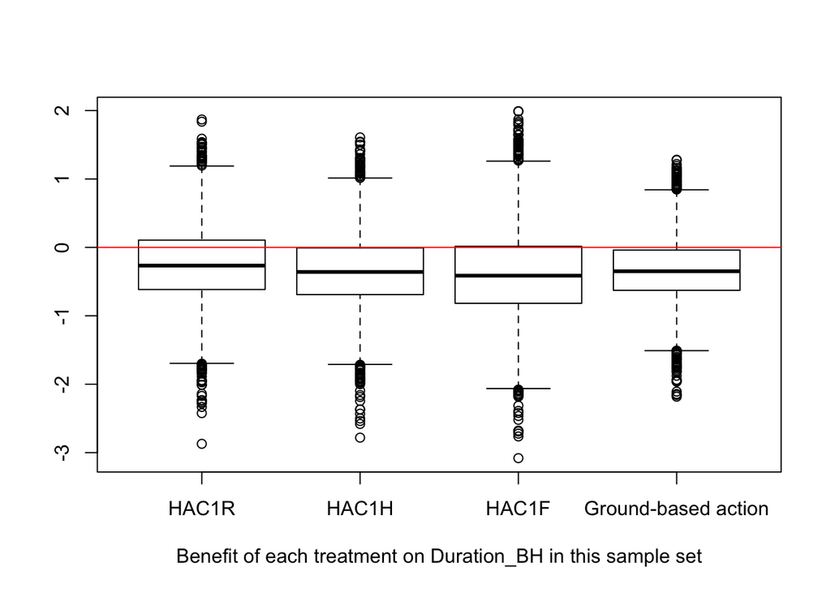

```r
# The best treatment predicted that minimize log(Being_Held_Size / Initial_Assessment_Size)
table(m_1sbest)
```

```
## m_1sbest
##          Air Tanker Ground-based action               HAC1F               HAC1H               HAC1R
##                1028                 796                2578                 537                 500
```

```r
# We see that the following are all postive
as.matrix(coef(m_size1)[as.matrix(coef(m_size1))>0])
```

```
##                                                [,1]
## FWI_D0                                   0.02047426
## FWI_D1                                   0.00913297
## Detection_AgentLKT                       0.12960099
## Eco_RegionMid-Boreal Uplands             0.22823177
## Eco_RegionOther                          0.15247798
## Fuel_TypeOther                           0.08270463
## TreatmentHAC1R                           2.32844464
## TreatmentHAC1H                           1.69398879
## TreatmentHAC1F                           2.46139822
## TreatmentGround-based action             1.26818844
## MonthJune or May                         0.11109193
## log_Response_Time                        0.08210272
## log_Count_Fire_Overlap                   0.66778061
## TreatmentHAC1R:PeriodPM                  0.36525926
## TreatmentHAC1H:PeriodPM                  0.72004278
## TreatmentHAC1F:PeriodPM                  0.44912450
## TreatmentGround-based action:PeriodPM    0.66838327
## TreatmentHAC1R:log_IA_size               0.12796486
## TreatmentHAC1H:log_IA_size               0.09854854
## TreatmentHAC1F:log_IA_size               0.08276117
## TreatmentGround-based action:log_IA_size 0.04881355
```

```r
# We see that the following are all negative
as.matrix(coef(m_size1)[as.matrix(coef(m_size1))<0])
```

```
##                                                             [,1]
## (Intercept)                                         -2.235859925
## Year                                                -0.010078135
## Detection_AgentUNP                                  -0.043430605
## Fuel_TypeM2                                         -0.181967481
## PeriodPM                                            -0.779909755
## MonthJuly                                           -0.097281880
## log_IA_size                                         -0.052791653
## FWI_D0:TreatmentHAC1R                               -0.026000715
## FWI_D0:TreatmentHAC1H                               -0.013791710
## FWI_D0:TreatmentHAC1F                               -0.019448380
## FWI_D0:TreatmentGround-based action                 -0.005048538
## TreatmentHAC1R:log_Response_Time                    -0.104034711
## TreatmentHAC1H:log_Response_Time                    -0.089250995
## TreatmentHAC1F:log_Response_Time                    -0.085090335
## TreatmentGround-based action:log_Response_Time      -0.083382208
## TreatmentHAC1R:log_Count_Fire_Overlap               -0.414000447
## TreatmentHAC1H:log_Count_Fire_Overlap               -0.441785993
## TreatmentHAC1F:log_Count_Fire_Overlap               -0.592687785
## TreatmentGround-based action:log_Count_Fire_Overlap -0.387069117
```

It seems all other treatment’s positive main effect put them under disadvantage, but however, the coefficient of interaction with FIW, log_Response_Time and log_Count_Fire_Overlap pull the value down quickly and make them more ideal choice than “Air Tanker” in many situations.

### Characteristics of Fires Under Each Best Treatment According to The Model With log(Being_Held_Size / Initial_Assessment_Size) As Response

```
##                                     Stratified by Treatment
##                                      Air Tanker    HAC1R         HAC1H         HAC1F         Ground-based action SMD
##   n                                   1028           500           537          2578           796
##   FWI_Dm1 (mean (SD))                10.62 (8.63)  18.34 (9.01)  10.70 (8.70)  14.34 (9.04)   7.93 (7.67)         0.570
##   FWI_Dm2 (mean (SD))                 9.91 (8.63)  16.32 (9.78)   9.95 (8.60)  13.18 (9.44)   7.79 (8.46)         0.447
##   FWI_D0 (mean (SD))                 10.17 (7.75)  21.47 (8.42)   9.61 (8.17)  14.80 (8.84)   5.44 (5.25)         0.973
##   FWI_D1 (mean (SD))                  6.90 (7.62)  11.99 (11.33)  7.46 (7.68)  10.74 (9.82)   5.55 (5.91)         0.382
##   FWI_D2 (mean (SD))                  7.24 (8.23)  11.21 (11.47)  7.00 (7.61)   9.65 (9.60)   5.75 (6.45)         0.303
##   Year (mean (SD))                    6.36 (3.40)   5.69 (3.29)   7.22 (3.74)   5.26 (2.81)   7.05 (3.63)         0.315
##   Detection_Agent (%)                                                                                             0.286
##      AIR                               306 (29.8)    105 (21.0)     97 (18.1)    607 (23.5)     85 (10.7)
##      LKT                               451 (43.9)    245 (49.0)    223 (41.5)   1306 (50.7)    474 (59.5)
##      UNP                               271 (26.4)    150 (30.0)    217 (40.4)    665 (25.8)    237 (29.8)
##   Eco_Region (%)                                                                                                  0.210
##      Clear Hills Upland                243 (23.6)    173 (34.6)    192 (35.8)    683 (26.5)    161 (20.2)
##      Mid-Boreal Uplands                659 (64.1)    250 (50.0)    270 (50.3)   1549 (60.1)    509 (63.9)
##      Other                             126 (12.3)     77 (15.4)     75 (14.0)    346 (13.4)    126 (15.8)
##   Fuel_Type (%)                                                                                                   0.181
##      C2                                715 (69.6)    324 (64.8)    306 (57.0)   1869 (72.5)    567 (71.2)
##      M2                                176 (17.1)    106 (21.2)    141 (26.3)    355 (13.8)    114 (14.3)
##      Other                             137 (13.3)     70 (14.0)     90 (16.8)    354 (13.7)    115 (14.4)
##   Period = PM (%)                     1019 (99.1)    495 (99.0)    199 (37.1)   2523 (97.9)    567 (71.2)         0.870
##   Month (%)                                                                                                       0.465
##      August to October                 181 (17.6)    135 (27.0)    163 (30.4)    233 ( 9.0)    210 (26.4)
##      July                              266 (25.9)    148 (29.6)    229 (42.6)   1511 (58.6)    344 (43.2)
##      June or May                       581 (56.5)    217 (43.4)    145 (27.0)    834 (32.4)    242 (30.4)
##   log_Duration_BH (mean (SD))         1.37 (1.33)   1.54 (1.45)   2.16 (1.72)   2.20 (1.75)   2.10 (1.45)         0.301
##   log_Response_Time (mean (SD))       5.35 (3.14)   7.45 (1.65)   7.20 (2.01)   6.42 (2.59)   7.55 (1.48)         0.455
##   log_Count_Fire_Overlap (mean (SD))  2.56 (0.77)   3.19 (0.50)   3.47 (0.64)   4.52 (0.60)   3.38 (0.64)         1.315
##   log_IA_size (mean (SD))            -2.50 (2.02)  -4.18 (0.98)  -4.10 (1.06)  -2.40 (2.24)  -1.62 (2.03)         0.810
```